# GEO 200CN Lab 9

Kenneth Larrieu

May 29, 2019

# Spatial Distribution Models

## Data

### Observations

```r
# load bigfoot observation data
if (!require("rspatial")) devtools::install_github('rspatial/rspatial')
library(rspatial)
bf <- sp_data('bigfoot')
dim(bf)
```

```
## [1] 3092    3
```

```r
head(bf)
```

```
##         lon      lat Class
## 1 -142.9000 61.50000     A
## 2 -132.7982 55.18720     A
## 3 -132.8202 55.20350     A
## 4 -141.5667 62.93750     A
## 5 -149.7853 61.05950     A
## 6 -141.3165 62.77335     A
```

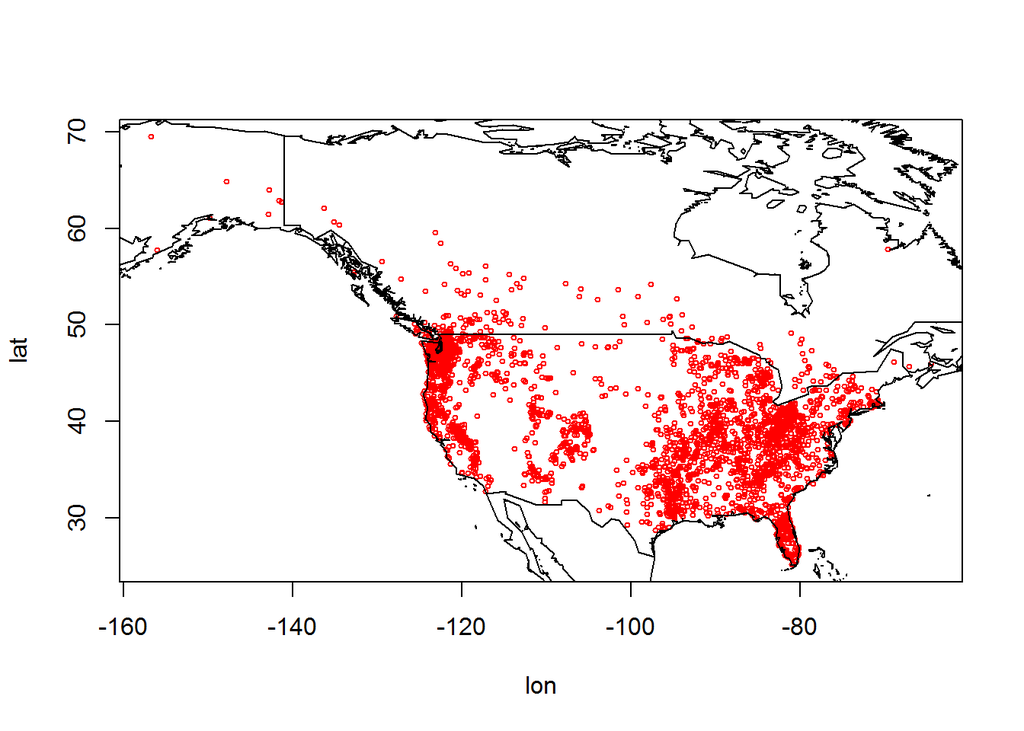

```r
# plot bigfoot sightings
plot(bf[,1:2], cex=0.5, col='red')
library(maptools)
data(wrld_simpl)
plot(wrld_simpl, add=TRUE)
```

### Predictors

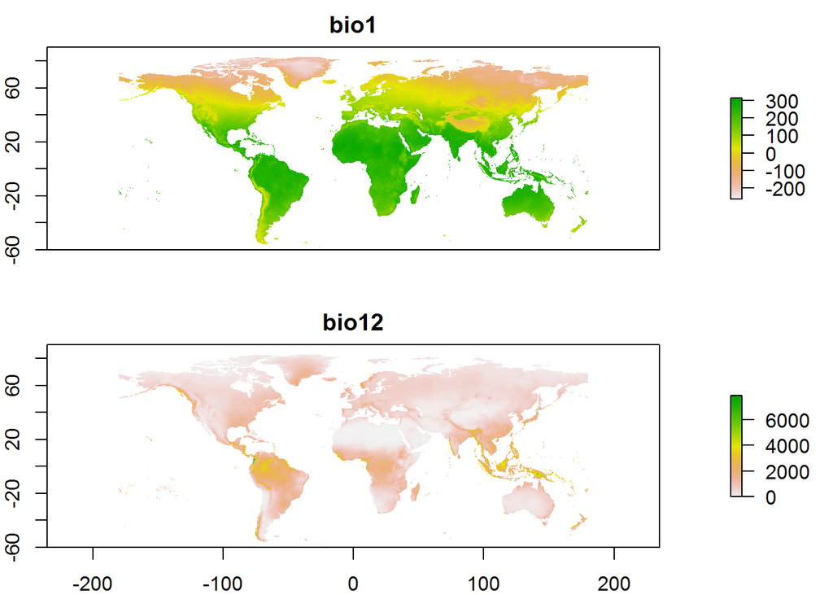

```r
library(raster)
# load climate data to use as predictor variables
wc <- raster::getData('worldclim', res=10, var='bio')
plot(wc[[c(1, 12)]], nr=2)
```

```r
# extract climate data at bigfoot sighting locations
bfc <- extract(wc, bf[,1:2])
head(bfc)
```

```
##      bio1 bio2 bio3  bio4 bio5 bio6 bio7 bio8 bio9 bio10 bio11 bio12 bio13
## [1,]  -14  102   27  9672  174 -197  371   51  -11   108  -137   973   119
## [2,]   62   55   31  4136  157  -17  174   43   98   118    15  2602   385
## [3,]   62   55   31  4136  157  -17  174   43   98   118    15  2602   385
## [4,]  -57  125   23 15138  206 -332  538  127 -129   127  -256   282    67
## [5,]   10   80   25  8308  174 -140  314   66    5   119   -91   532    81
## [6,]  -59  128   23 14923  204 -334  538  122 -130   122  -255   322    75
##      bio14 bio15 bio16 bio17 bio18 bio19
## [1,]    43    30   332   156   290   210
## [2,]   128    33   953   407   556   721
## [3,]   128    33   953   407   556   721
## [4,]     6    81   163    22   163    27
## [5,]    22    41   215    72   159   117
## [6,]     8    79   183    28   183    32
```

```r
# check for missing climate data
i <- which(is.na(bfc[,1]))
i
```

```
## [1]  862 2667
```

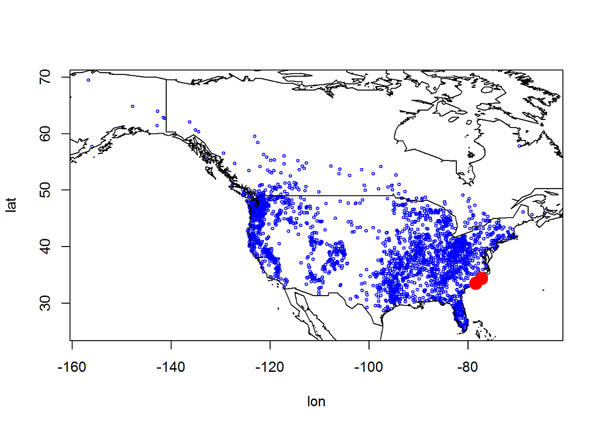

```r
plot(bf[,1:2], cex=0.5, col='blue')
plot(wrld_simpl, add=TRUE)
# plot locations with missing climate data
points(bf[i, ], pch=20, cex=3, col='red')
```

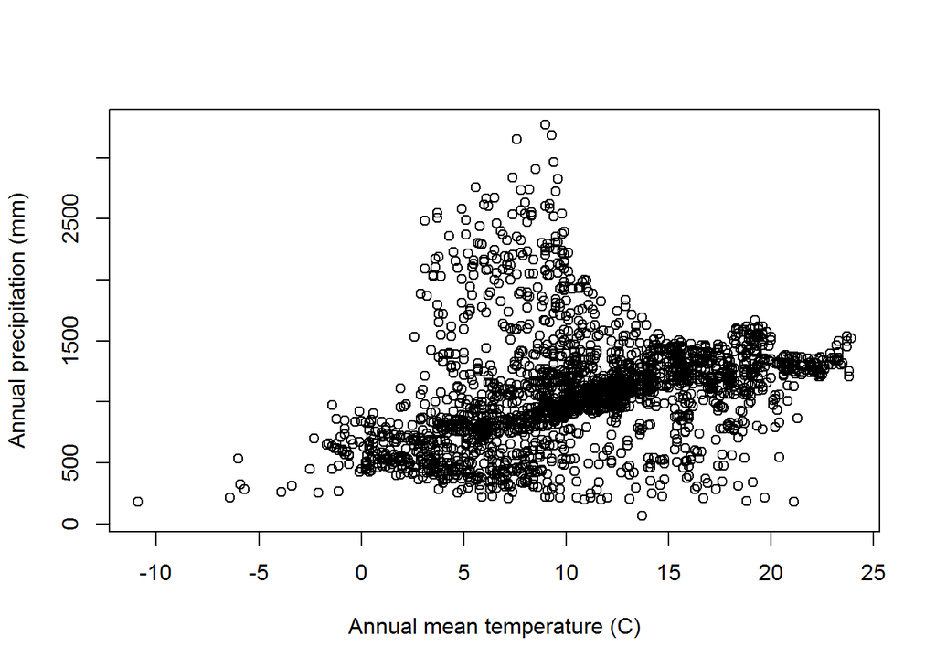

```r
# plot temp vs precip for bigfoot locations
plot(bfc[ ,'bio1'] / 10, bfc[, 'bio12'], xlab='Annual mean temperature (C)',
         ylab='Annual precipitation (mm)')
```

### Background Data

```r
library(dismo)
# extent of all points
e <- extent(SpatialPoints(bf[, 1:2]))
e
```

```
## class      : Extent
## xmin       : -156.75
## xmax       : -64.4627
## ymin       : 25.141
## ymax       : 69.5
```

```r
set.seed(0)
# create random sampling of points
bg <- sampleRandom(wc, 5000, ext=e)
dim(bg)
```

```
## [1] 5000   19
```

```r
head(bg)
```

```
##      bio1 bio2 bio3  bio4 bio5 bio6 bio7 bio8 bio9 bio10 bio11 bio12 bio13
## [1,]  157  126   60  2935  262   55  207  124  191   197   122   379    88
## [2,]  -54  105   28  9244  142 -223  365   57  -62    68  -165   639    79
## [3,]  -57  104   20 14227  198 -317  515  106 -227   118  -247   473    71
## [4,]    1  119   24 12335  231 -251  482  138  -91   150  -168   844   104
## [5,]  208  169   44  7641  404   28  376  304  239   307   114   198    31
## [6,]  -89  111   23 12931  160 -316  476   78 -174    78  -248   476    76
##      bio14 bio15 bio16 bio17 bio18 bio19
## [1,]     0   100   225     2     4   222
## [2,]    28    30   226   101   219   138
## [3,]    17    46   197    55   194    59
## [4,]    34    33   301   128   291   137
## [5,]     2    50    73    11    52    62
## [6,]    25    40   193    79   193    82
```

Combining presence and background data:

```r
d <- rbind(cbind(pa=1, bfc), cbind(pa=0, bg))
d <- data.frame(d)
dim(d)
```

```
## [1] 8092   20
```

## Fit a Model

```r
# split into east and west data
de <- d[bf[,1] > -102, ]
dw <- d[bf[,1] <= -102, ]
```

### CART

```r
library(rpart)
# fit cart model for western bigfoot sightings: presence/absence as function of climate
cart <- rpart(pa~., data=dw)
printcp(cart)
```

```
##
## Regression tree:
## rpart(formula = pa ~ ., data = dw)
##
## Variables actually used in tree construction:
## [1] bio10 bio14 bio15 bio18 bio3  bio4  bio5  bio6  bio8
##
## Root node error: 762.45/3246 = 0.23489
##
## n= 3246
##
##         CP nsplit rel error  xerror     xstd
## 1 0.410197      0   1.00000 1.00048 0.008909
## 2 0.137588      1   0.58980 0.59041 0.014191
## 3 0.044259      2   0.45222 0.45474 0.016586
## 4 0.029121      3   0.40796 0.42701 0.016572
## 5 0.018954      4   0.37884 0.40239 0.016586
## 6 0.018324      5   0.35988 0.39294 0.016337
## 7 0.010113      6   0.34156 0.37926 0.015777
## 8 0.010008      7   0.33144 0.36821 0.016014
## 9 0.010000      9   0.31143 0.36821 0.016014
```

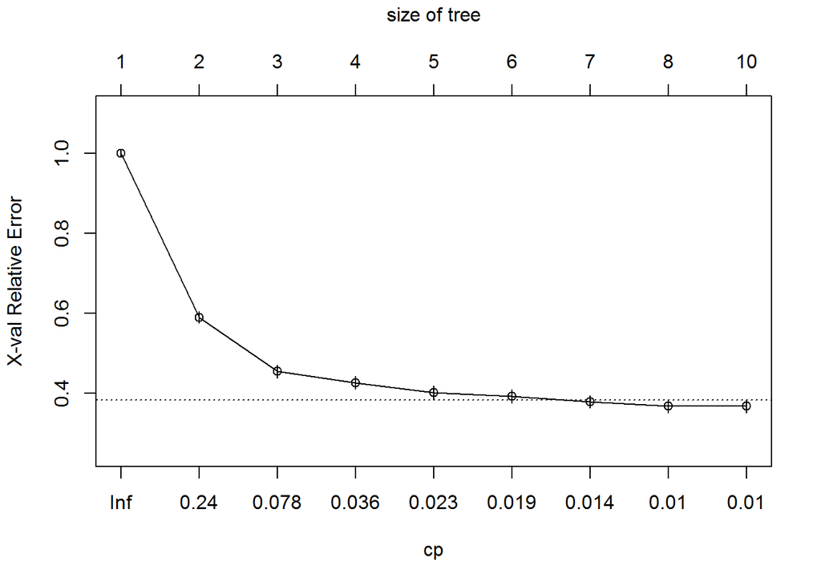

```r
plotcp(cart)
```

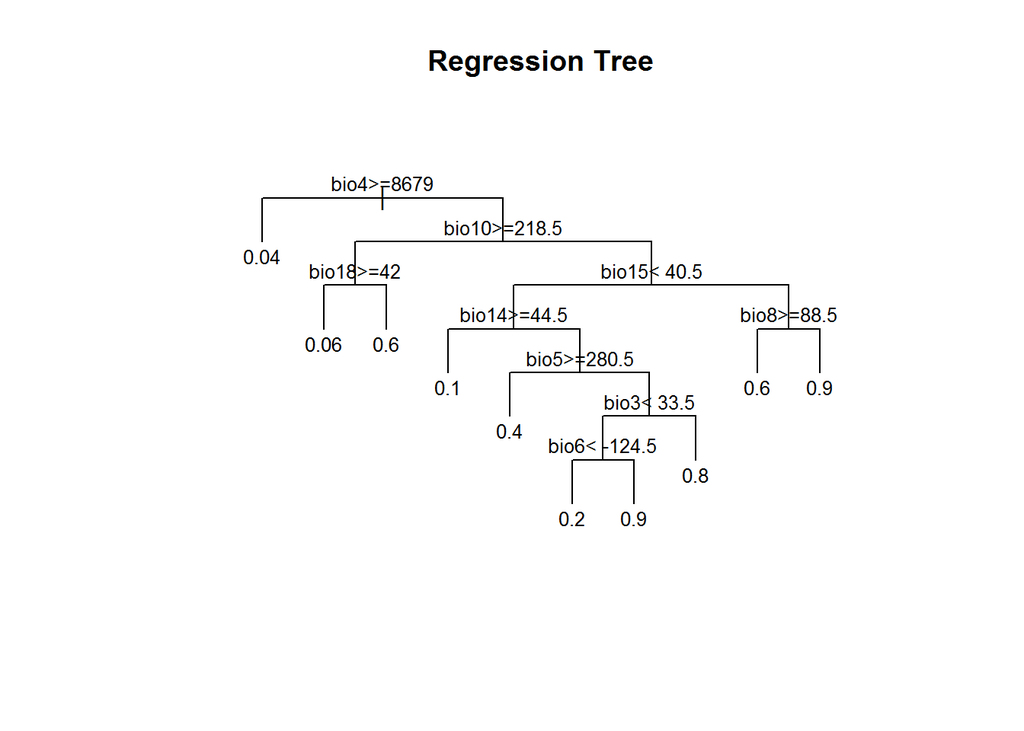

```r
plot(cart, uniform=TRUE, main="Regression Tree", margin=0.2)
# text(cart, use.n=TRUE, all=TRUE, cex=.8)
text(cart, cex=.8, digits=1)
```

**Question 1:** Describe the conditions under which you have the highest probability of finding our beloved species?

BIO1 = Annual Mean Temperature BIO2 = Mean Diurnal Range (Mean of monthly (max temp - min temp)) BIO3 = Isothermality (BIO2/BIO7) (* 100) BIO4 = Temperature Seasonality (standard deviation *100) BIO5 = Max Temperature of Warmest Month BIO6 = Min Temperature of Coldest Month BIO7 = Temperature Annual Range (BIO5-BIO6) BIO8 = Mean Temperature of Wettest Quarter BIO9 = Mean Temperature of Driest Quarter BIO10 = Mean Temperature of Warmest Quarter BIO11 = Mean Temperature of Coldest Quarter BIO12 = Annual Precipitation BIO13 = Precipitation of Wettest Month BIO14 = Precipitation of Driest Month BIO15 = Precipitation Seasonality (Coefficient of Variation) BIO16 = Precipitation of Wettest Quarter BIO17 = Precipitation of Driest Quarter BIO18 = Precipitation of Warmest Quarter BIO19 = Precipitation of Coldest Quarter

### Random Forest

```r
library(randomForest)
fpa <- as.factor(dw[, 'pa'])

crf <- randomForest(dw[, 2:ncol(dw)], fpa)
crf
```

```
##
## Call:
##  randomForest(x = dw[, 2:ncol(dw)], y = fpa)
##                Type of random forest: classification
##                      Number of trees: 500
## No. of variables tried at each split: 4
##
##         OOB estimate of  error rate: 9.8%
## Confusion matrix:
##      0    1 class.error
## 0 1864  158  0.07814045
## 1  160 1064  0.13071895
```

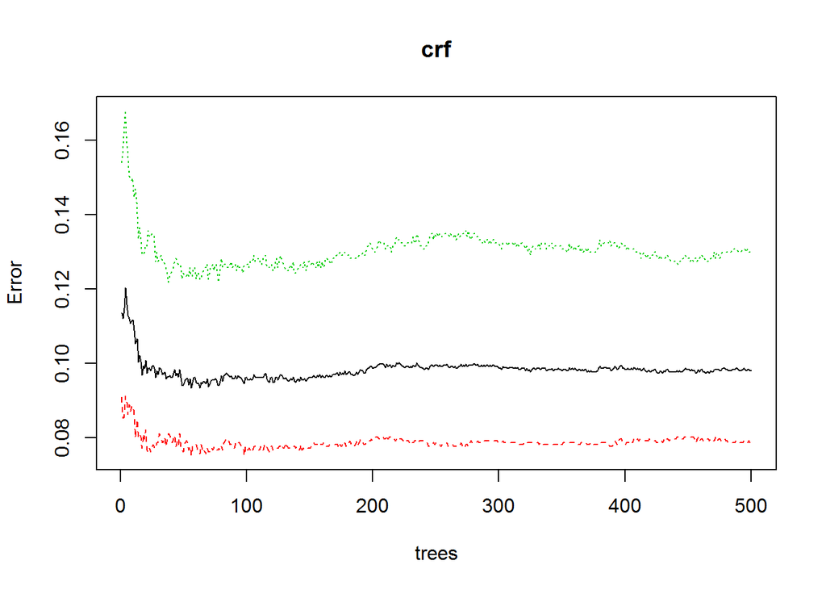

```r
plot(crf)
```

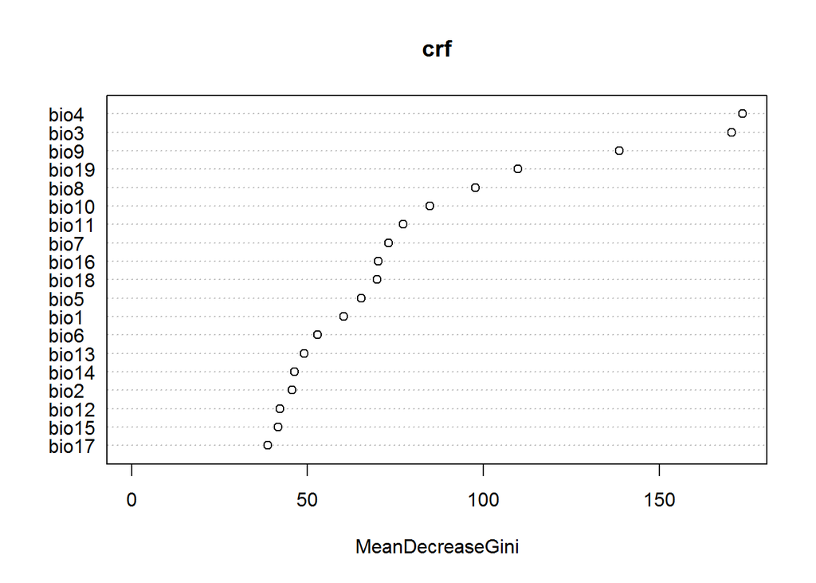

```r
# variable importance plot
varImpPlot(crf)
```

```r
trf <- tuneRF(dw[, 2:ncol(dw)], dw[, 'pa'])
```

```
## mtry = 6  OOB error = 0.07100579
## Searching left ...
```

```
## mtry = 3     OOB error = 0.07010267
## 0.01271897 0.05
## Searching right ...
```

```
## mtry = 12    OOB error = 0.0708133
## 0.002710948 0.05
```

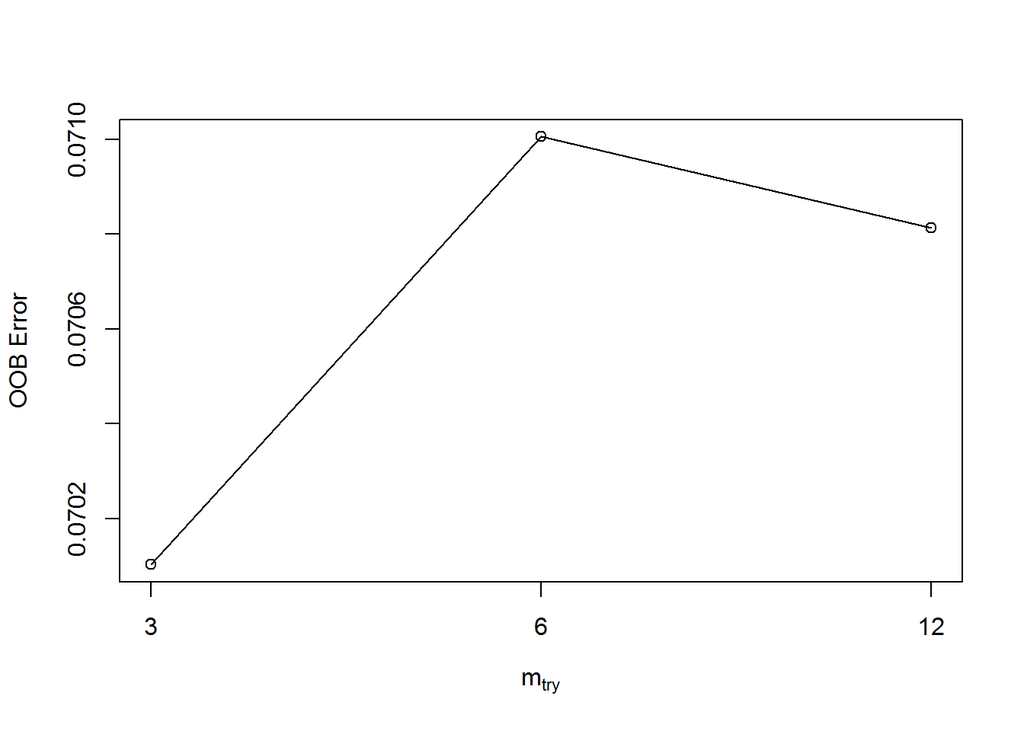

```r
trf
```

```
##    mtry   OOBError
## 3     3 0.07010267
## 6     6 0.07100579
## 12   12 0.07081330
```

```r
mt <- trf[which.min(trf[,2]), 1]
mt
```

```
## [1] 3
```

**Question 2:** What did tuneRF help us find? What does the values of mt represent?

`tuneRF` Found the optimal value of the `mtry` parameter for the `randomForest` algorithm, which is the number of variables used as candidates for each node split. `mt` is the value of `mtry` which minimizes the OOB error; i.e. it is the value which produces the best random forest.

```r
rrf <- randomForest(dw[, 2:ncol(d)], dw[, 'pa'], mtry=mt)
rrf
```

```
##
## Call:
##  randomForest(x = dw[, 2:ncol(d)], y = dw[, "pa"], mtry = mt)
##                Type of random forest: regression
##                      Number of trees: 500
## No. of variables tried at each split: 3
##
##           Mean of squared residuals: 0.06855845
##                     % Var explained: 70.81
```

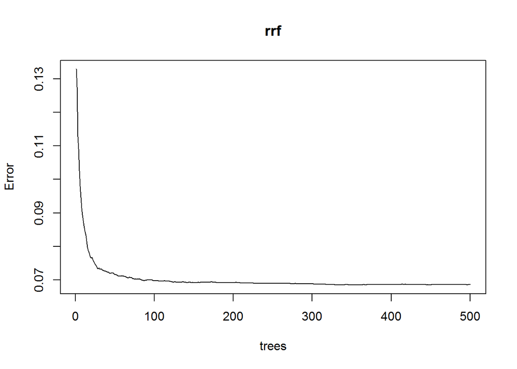

```r
plot(rrf)
```

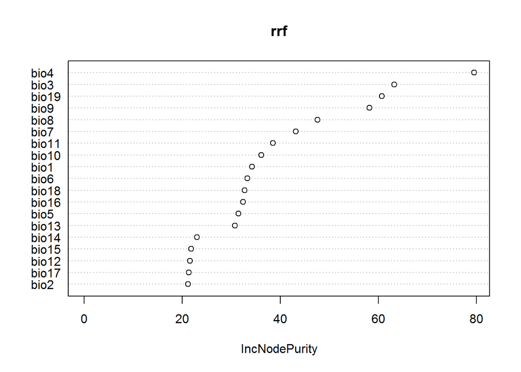

```r
varImpPlot(rrf)
```

## Predict

```r
# Extent of the western points
ew <- extent(SpatialPoints(bf[bf[,1] <= -102, 1:2]))
ew
```

```
## class      : Extent
## xmin       : -156.75
## xmax       : -102.3881
## ymin       : 30.77722
## ymax       : 69.5
```

### Regression

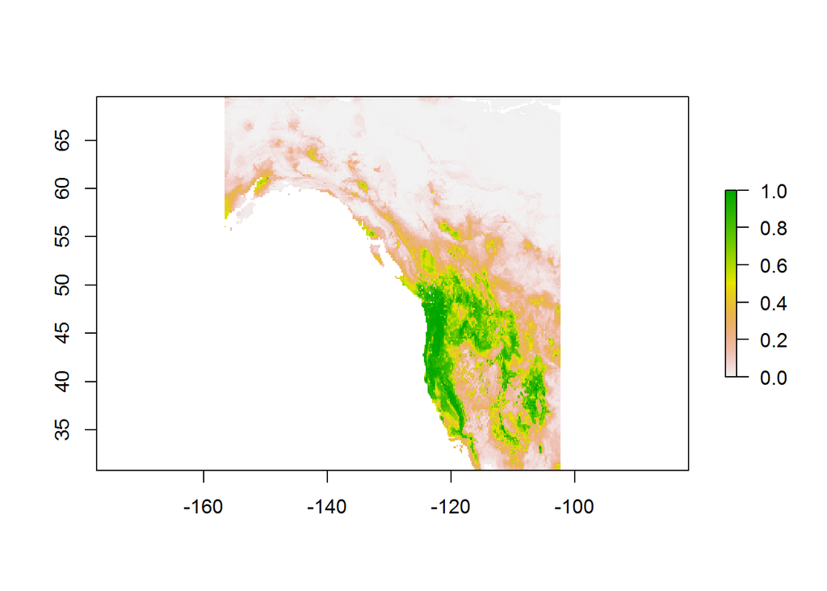

```r
rp <- predict(wc, rrf, ext=ew)
plot(rp)
```

```r
eva <- evaluate(dw[dw$pa==1, ], dw[dw$pa==0, ], rrf)
eva
```

```
## class          : ModelEvaluation
## n presences    : 1224
## n absences     : 2022
## AUC            : 0.9993919
## cor            : 0.9646471
## max TPR+TNR at : 0.4870895
```

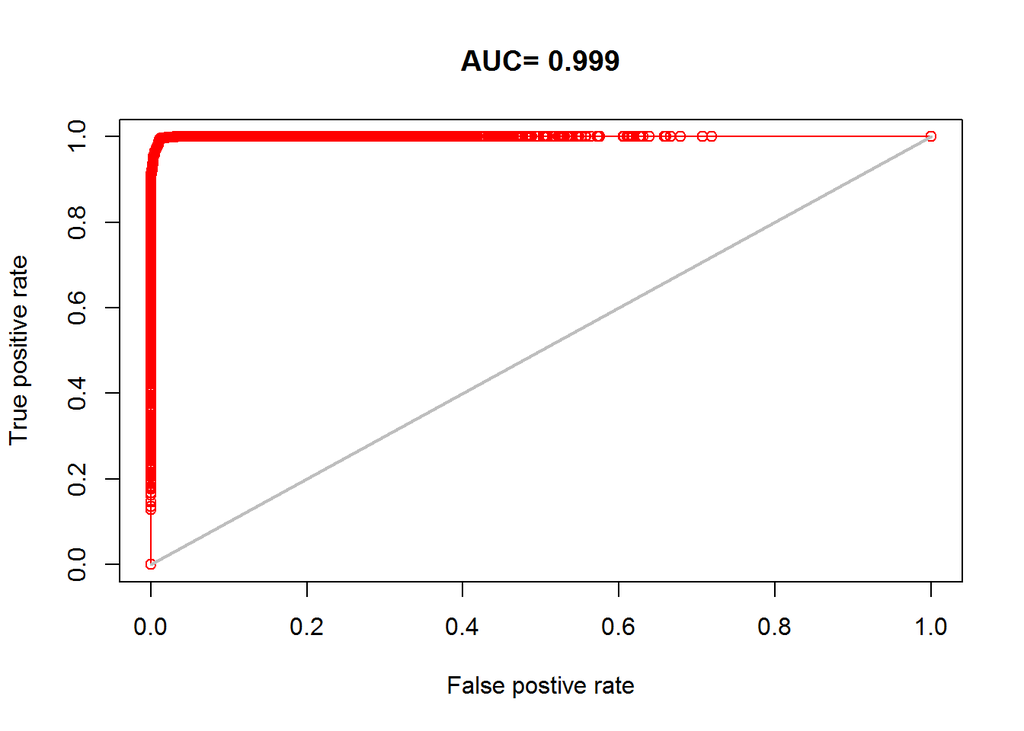

```r
plot(eva, 'ROC')
```

```r
# get threshold for classification
tr <- threshold(eva)
tr
```

```
##                kappa spec_sens no_omission prevalence equal_sens_spec
## thresholds 0.4870895 0.4870895    0.393281  0.3814001        0.518784
##            sensitivity
## thresholds   0.7154833
```

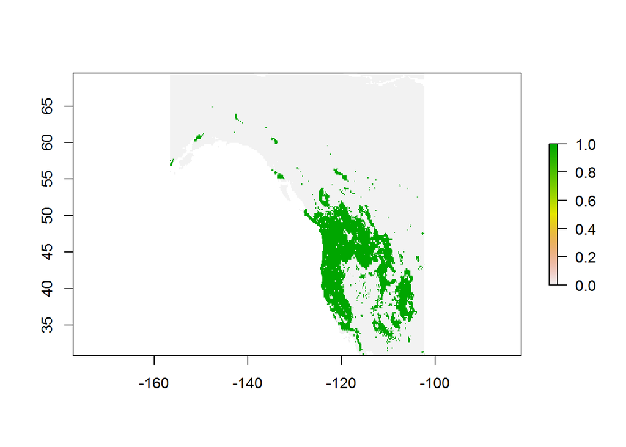

```r
# plot values above threshold
plot(rp > tr[1, 'spec_sens'])
```

### Classification

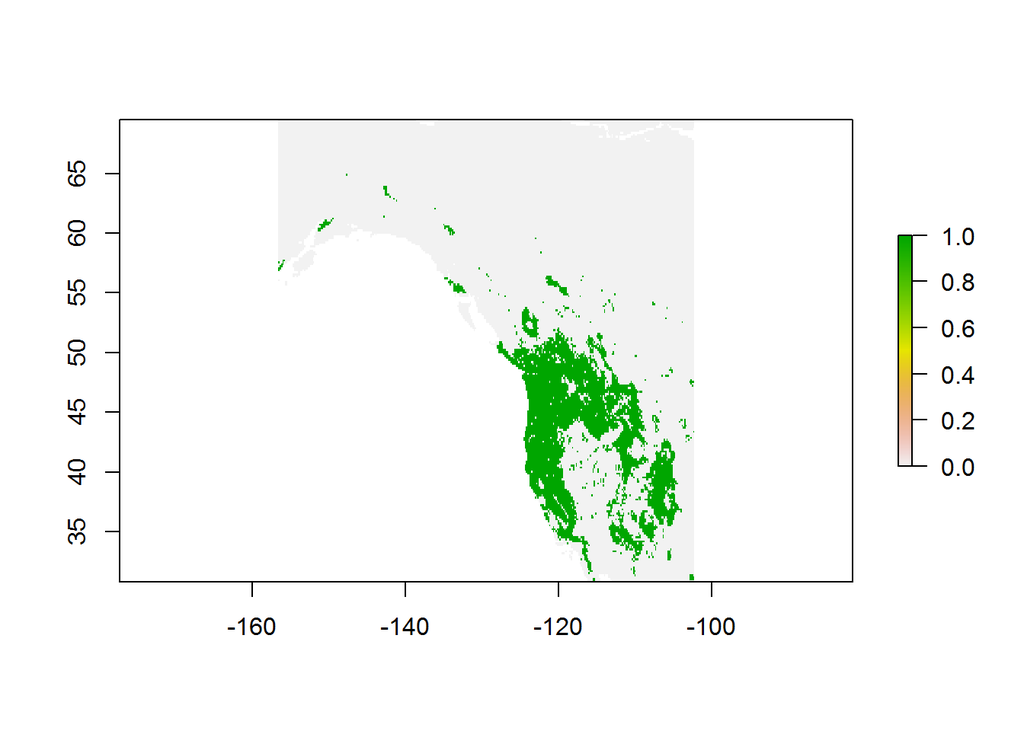

```r
rc <- predict(wc, crf, ext=ew)
plot(rc)
```

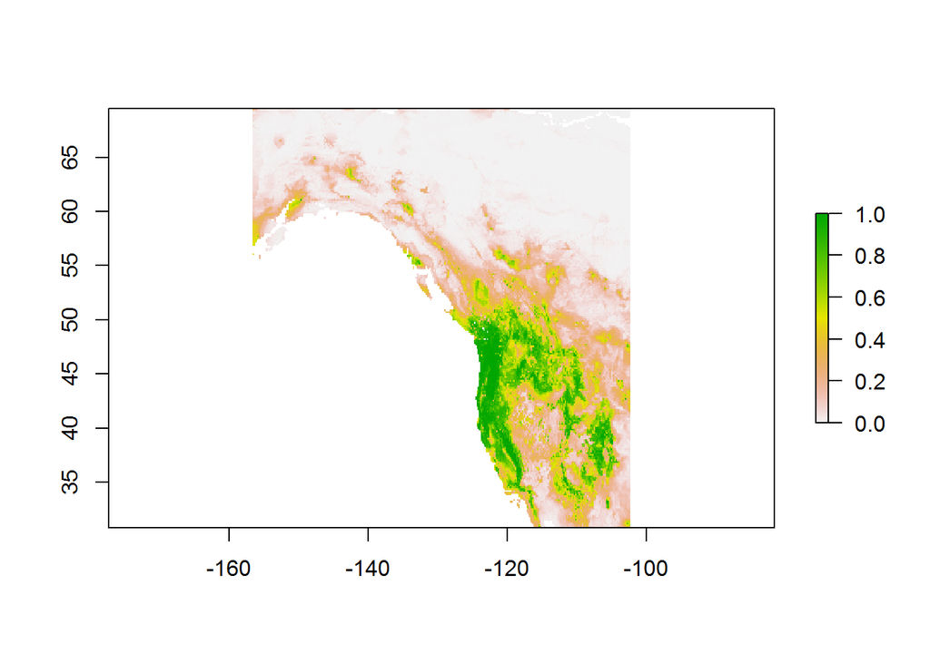

```r
rc2 <- predict(wc, crf, ext=ew, type='prob', index=2)
plot(rc2)
```

## Extrapolation

```r
de <- na.omit(de)
eva2 <- evaluate(de[de$pa==1, ], de[de$pa==0, ], rrf)
eva2
```

```
## class          : ModelEvaluation
## n presences    : 1866
## n absences     : 2978
## AUC            : 0.4294745
## cor            : -0.2609383
## max TPR+TNR at : 0.000208
```

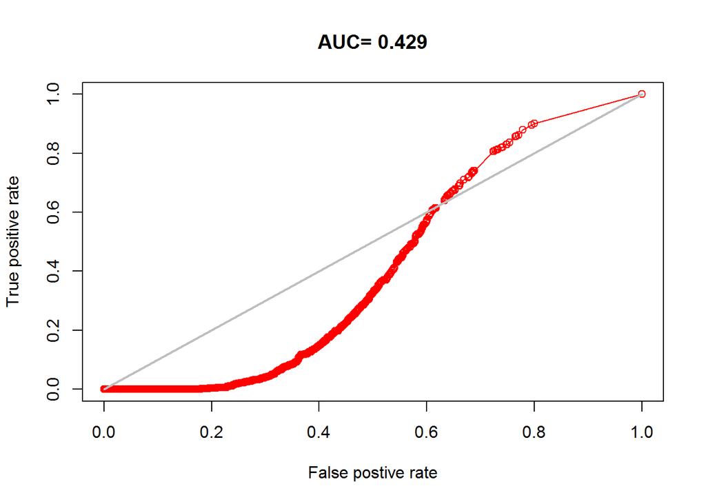

```r
plot(eva2, 'ROC')
```

```r
eus <- extent(SpatialPoints(bf[, 1:2]))
eus
```

```
## class      : Extent
## xmin       : -156.75
## xmax       : -64.4627
## ymin       : 25.141
## ymax       : 69.5
```

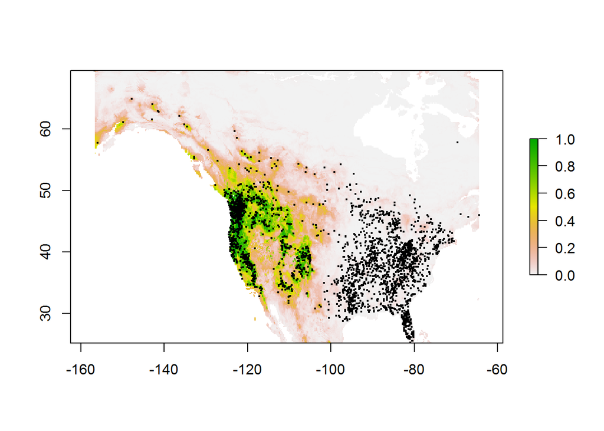

```r
rcusa <- predict(wc, rrf, ext=eus)
plot(rcusa)
points(bf[,1:2], cex=.25)
```

**Question 3:** Why would it be that the model does not extrapolate well?

Our model might not exrtapolate well because the sightings in the east may be a different species than the western Bigfoot, with significantly different climatic preferences. It appears that the reported observations in the east often occur in very different climates than those of the western observations, which supports this hypothesis.

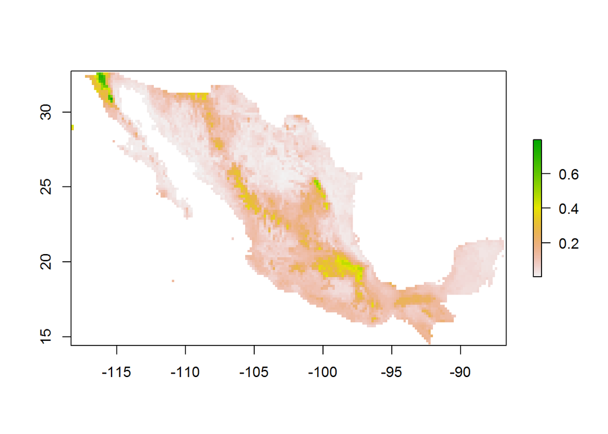

```r
mex <- getData('GADM', country='MEX', level=1)
pm <- predict(wc, rrf, ext=mex)
pm <- mask(pm, mex)
plot(pm)
```

**Question 4:** Where in Mexico are you most likely to encounter western bigfoot?

According to the random forest model predictions, we are most likely to observe western Bigfoot in the northern tip of Baja California.

```r
# load future climate data estimates
fut <- getData('CMIP5', res=10, var='bio', rcp=85, model='AC', year=70)
# keep consistent variable names
names(fut) <- names(wc)
# make predictions for future climate scenario
futusa <- predict(fut, rrf, ext=eus, progress='window')
```

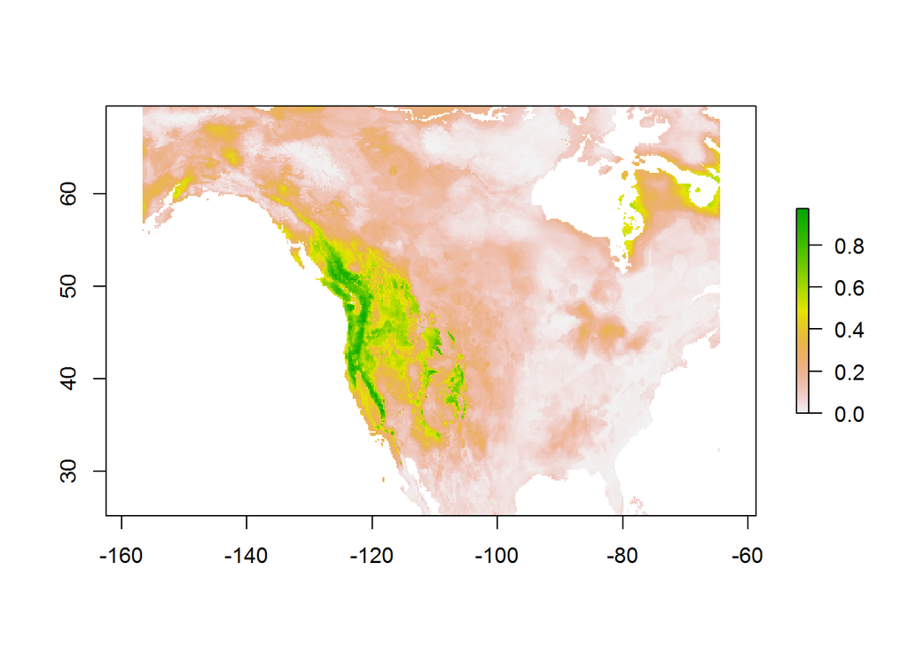

```r
plot(futusa)
```

**Question 5:** Make a map to show where conditions are improving for western bigfoot, and where they are not. Is the species headed toward extinction?

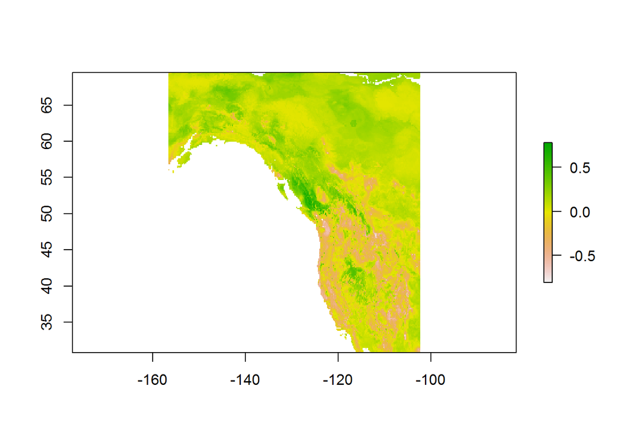

```r
plot(futusa - rc2)
```